# HOTEL_INN_ (1)

# Categorical vs Booking status(Target)

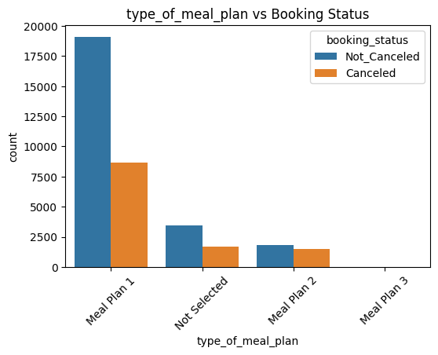

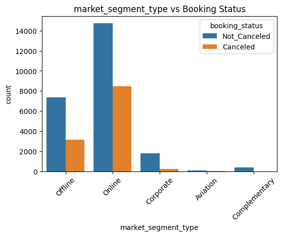

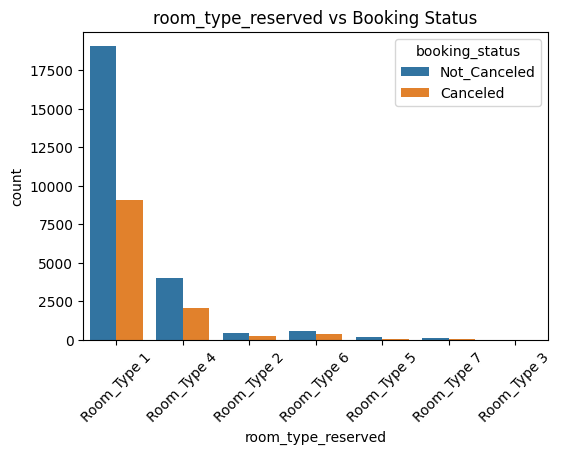

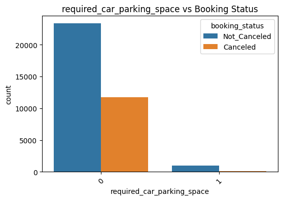

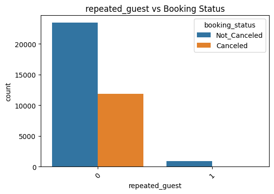

```python
cat_cols = [
    'type_of_meal_plan',
    'market_segment_type',
    'room_type_reserved',
    'required_car_parking_space',
    'repeated_guest'
]

for col in cat_cols:

    plt.figure(figsize=(6,4))

    sns.countplot(
        x=col,
        hue='booking_status',
        data=df
    )

    plt.title(f'{col} vs Booking Status')

    plt.xticks(rotation=45)

    plt.show()
```

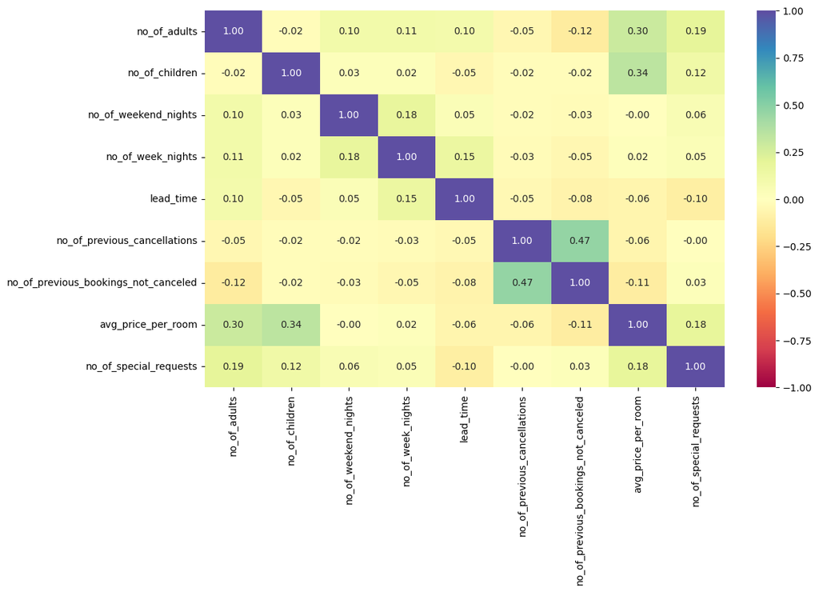

```python
cols_list = Numerical_variable.columns.tolist()

plt.figure(figsize=(12, 7))
sns.heatmap(
    df[cols_list].corr(), annot=True, vmin=-1, vmax=1, fmt=".2f", cmap="Spectral"
)
plt.show()
```

# **Data Pre-processing**

**Outlier detection**

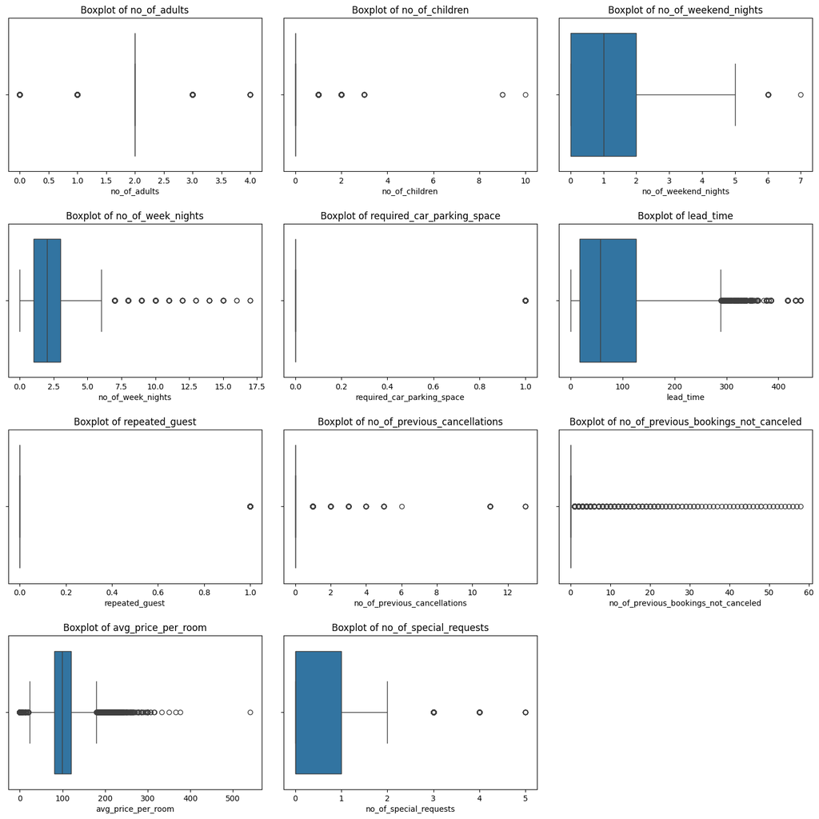

```python
# outlier detection using boxplot
num_cols = df.select_dtypes(include=np.number).columns.tolist()

plt.figure(figsize=(15, 15)) # Increased figure size to accommodate more subplots

for i, variable in enumerate(num_cols):
    plt.subplot(4, 3, i + 1) # Changed to a 4x3 grid to fit all 11 plots
    sns.boxplot(data=df, x=variable)
    plt.title(f'Boxplot of {variable}') # Added title for clarity
    plt.tight_layout(pad=2)

plt.show()
```

```python
# Reload the dataframe to ensure it's not empty or corrupted from previous runs
import pandas as pd # Ensure pandas is imported if this cell can be run independently
from sklearn.model_selection import train_test_split

df = pd.read_csv('/content/INNHotelsGroup.csv')
print(f"Shape after initial load: {df.shape}")

# Recreate 'full_date' and handle NaNs from it
df['full_date'] = pd.to_datetime({
    'year': df['arrival_year'],
    'month': df['arrival_month'],
    'day': df['arrival_date']
}, errors='coerce')
df.dropna(subset=['full_date'], inplace=True)
print(f"Shape after full_date dropna: {df.shape}")

# Drop columns that are no longer needed or were used to create 'full_date'
df = df.drop(columns=['arrival_month', 'arrival_date', 'arrival_year', 'Booking_ID'], errors='ignore')
print(f"Shape after dropping columns: {df.shape}")

# Process 'booking_status'
print(f"Booking status value counts before mapping:\n{df['booking_status'].value_counts(dropna=False)}")
df['booking_status'] = df['booking_status'].astype(str).str.strip().map({'Not_Canceled': 0, 'Canceled': 1})
print(f"Booking status value counts after mapping:\n{df['booking_status'].value_counts(dropna=False)}")

# Drop rows where 'booking_status' is NaN after mapping (e.g., original NaNs or unmapped strings)
df.dropna(subset=['booking_status'], inplace=True)
print(f"Shape after booking_status dropna: {df.shape}")

# Convert booking_status to int (it might be float if NaNs were present and later dropped)
df['booking_status'] = df['booking_status'].astype(int)
print(f"Shape after booking_status astype(int): {df.shape}")

X = df.drop(["booking_status", "full_date"], axis=1)
Y = df["booking_status"]

print(f"Shape of X before get_dummies: {X.shape}")
X = pd.get_dummies(X, drop_first=True)
print(f"Shape of X after get_dummies: {X.shape}")
print(f"Shape of Y: {Y.shape}")

# Splitting data in train and test sets
X_train, X_test, y_train, y_test = train_test_split(
    X, Y, test_size=0.30, random_state=1
)
print(f"Shape of X_train: {X_train.shape}")
print(f"Shape of y_train: {y_train.shape}")
```

```
Shape after initial load: (36275, 19)
Shape after full_date dropna: (36238, 20)
Shape after dropping columns: (36238, 16)
Booking status value counts before mapping:
booking_status
Not_Canceled    24360
Canceled        11878
Name: count, dtype: int64
Booking status value counts after mapping:
booking_status
0    24360
1    11878
Name: count, dtype: int64
Shape after booking_status dropna: (36238, 16)
Shape after booking_status astype(int): (36238, 16)
Shape of X before get_dummies: (36238, 14)
Shape of X after get_dummies: (36238, 24)
Shape of Y: (36238,)
Shape of X_train: (25366, 24)
Shape of y_train: (25366,)
```

```python
# Check unique values and their counts in 'booking_status' before mapping
print(df['booking_status'].value_counts(dropna=False))
```

```
booking_status
0    24360
1    11878
Name: count, dtype: int64
```

```python
df['booking_status'].unique()
```

```
array([0, 1])
```

```python
df['booking_status'].isnull().sum()
```

```
np.int64(0)
```

```python
print("Shape of Training set : ", X_train.shape)
print("Shape of test set : ", X_test.shape)
print("Percentage of classes in training set:")
print(y_train.value_counts(normalize=True))
print("Percentage of classes in test set:")
print(y_test.value_counts(normalize=True))
```

```
Shape of Training set :  (25366, 24)
Shape of test set :  (10872, 24)
Percentage of classes in training set:
booking_status
0   0.67074
1   0.32926
Name: proportion, dtype: float64
Percentage of classes in test set:
booking_status
0   0.67568
1   0.32432
Name: proportion, dtype: float64
```

**We had seen that around 67.2% of observations belongs to class 0 (Booking not cancelled) and 32.8% observations belongs to class 1 (booking cancelled), and this is preserved in the train and test sets**

# **Model-Builiding**

**Logistic Regression Model**

```python
df["booking_status"].value_counts()
```

| booking_status | count |
| --- | --- |
| 0 | 24360 |
| 1 | 11878 |

**dtype:** int64

```python
df["booking_status"].value_counts(1
                                )
```

| booking_status | proportion |
| --- | --- |
| 0 | 0.67222 |
| 1 | 0.32778 |

**dtype:** float64

The number of times where the customer has cancelled booking is 11,878 which is 32% of the total data available.

```python
X = df.drop(["booking_status", "full_date"], axis=1)
Y = df["booking_status"]

# creating dummies for categorical variables
X = pd.get_dummies(X, drop_first=True)

# adding a constant to X variable (after get_dummies to ensure X is fully numeric)
X = add_constant(X)

# Splitting data in train and test sets
X_train, X_test, y_train, y_test = train_test_split(
    X, Y, test_size=0.30, random_state=1, stratify=Y
)
```

```python
print(X_train.shape)
print(X_test.shape)
```

```
(25366, 25)
(10872, 25)
```

Fitting Logistic Regression

```python
# Ensure X_train is fully numeric (e.g., convert bool dtypes from get_dummies to int, then to float)
X_train_numeric = X_train.copy()
for col in X_train_numeric.select_dtypes(include='bool').columns:
    X_train_numeric[col] = X_train_numeric[col].astype(int)
X_train_numeric = X_train_numeric.astype(float)

# Drop columns causing perfect separation or multicollinearity
# From inspection of cross-tabulation, 'market_segment_type_Complementary' causes perfect separation
if 'market_segment_type_Complementary' in X_train_numeric.columns:
    X_train_numeric = X_train_numeric.drop(columns=['market_segment_type_Complementary'])

# fitting the model on training set with increased maxiter
logit = sm.Logit(y_train, X_train_numeric)
lg = logit.fit(maxiter=1000, disp=False) # Increased maxiter and suppressed iteration output
print(lg.summary())
```

```
                           Logit Regression Results
==============================================================================
Dep. Variable:         booking_status   No. Observations:                25366
Model:                          Logit   Df Residuals:                    25342
Method:                           MLE   Df Model:                           23
Date:                Sat, 16 May 2026   Pseudo R-squ.:                  0.3238
Time:                        08:31:19   Log-Likelihood:                -10851.
converged:                       True   LL-Null:                       -16046.
Covariance Type:            nonrobust   LLR p-value:                     0.000
========================================================================================================
                                           coef    std err          z      P>|z|      [0.025      0.975]
--------------------------------------------------------------------------------------------------------
const                                   -3.3020      0.230    -14.327      0.000      -3.754      -2.850
no_of_adults                             0.0220      0.037      0.589      0.556      -0.051       0.095
no_of_children                           0.1684      0.057      2.951      0.003       0.057       0.280
no_of_weekend_nights                     0.1520      0.020      7.675      0.000       0.113       0.191
no_of_week_nights                        0.0452      0.012      3.674      0.000       0.021       0.069
required_car_parking_space              -1.5948      0.136    -11.711      0.000      -1.862      -1.328
lead_time                                0.0158      0.000     62.462      0.000       0.015       0.016
repeated_guest                          -2.2210      0.587     -3.781      0.000      -3.372      -1.070
no_of_previous_cancellations             0.2493      0.091      2.734      0.006       0.071       0.428
no_of_previous_bookings_not_canceled    -0.1750      0.166     -1.054      0.292      -0.500       0.150
avg_price_per_room                       0.0190      0.001     27.312      0.000       0.018       0.020
no_of_special_requests                  -1.4916      0.030    -49.908      0.000      -1.550      -1.433
type_of_meal_plan_Meal Plan 2            0.0502      0.063      0.793      0.428      -0.074       0.174
type_of_meal_plan_Meal Plan 3            3.1820      3.102      1.026      0.305      -2.899       9.263
type_of_meal_plan_Not Selected           0.3012      0.052      5.757      0.000       0.199       0.404
room_type_reserved_Room_Type 2          -0.3031      0.129     -2.352      0.019      -0.556      -0.051
room_type_reserved_Room_Type 3           0.7195      1.511      0.476      0.634      -2.242       3.681
room_type_reserved_Room_Type 4          -0.1969      0.053     -3.721      0.000      -0.301      -0.093
room_type_reserved_Room_Type 5          -0.8156      0.215     -3.786      0.000      -1.238      -0.393
room_type_reserved_Room_Type 6          -1.0602      0.148     -7.175      0.000      -1.350      -0.771
room_type_reserved_Room_Type 7          -1.5014      0.327     -4.595      0.000      -2.142      -0.861
market_segment_type_Corporate           -0.6777      0.240     -2.825      0.005      -1.148      -0.207
market_segment_type_Offline             -1.5774      0.227     -6.959      0.000      -2.022      -1.133
market_segment_type_Online               0.2075      0.224      0.927      0.354      -0.231       0.646
========================================================================================================
```

```python
print("Value counts for 'type_of_meal_plan_Meal Plan 3':")
print(X_train_numeric['type_of_meal_plan_Meal Plan 3'].value_counts())
print("\nCross-tabulation with booking_status (y_train):")
print(pd.crosstab(X_train_numeric['type_of_meal_plan_Meal Plan 3'], y_train))
```

```
Value counts for 'type_of_meal_plan_Meal Plan 3':
type_of_meal_plan_Meal Plan 3
0.00000    25363
1.00000        3
Name: count, dtype: int64

Cross-tabulation with booking_status (y_train):
booking_status                     0     1
type_of_meal_plan_Meal Plan 3
0.00000                        17050  8313
1.00000                            2     1
```

```python
print(lg.summary())
```

```
                           Logit Regression Results
==============================================================================
Dep. Variable:         booking_status   No. Observations:                25366
Model:                          Logit   Df Residuals:                    25342
Method:                           MLE   Df Model:                           23
Date:                Sat, 16 May 2026   Pseudo R-squ.:                  0.3238
Time:                        08:31:19   Log-Likelihood:                -10851.
converged:                       True   LL-Null:                       -16046.
Covariance Type:            nonrobust   LLR p-value:                     0.000
========================================================================================================
                                           coef    std err          z      P>|z|      [0.025      0.975]
--------------------------------------------------------------------------------------------------------
const                                   -3.3020      0.230    -14.327      0.000      -3.754      -2.850
no_of_adults                             0.0220      0.037      0.589      0.556      -0.051       0.095
no_of_children                           0.1684      0.057      2.951      0.003       0.057       0.280
no_of_weekend_nights                     0.1520      0.020      7.675      0.000       0.113       0.191
no_of_week_nights                        0.0452      0.012      3.674      0.000       0.021       0.069
required_car_parking_space              -1.5948      0.136    -11.711      0.000      -1.862      -1.328
lead_time                                0.0158      0.000     62.462      0.000       0.015       0.016
repeated_guest                          -2.2210      0.587     -3.781      0.000      -3.372      -1.070
no_of_previous_cancellations             0.2493      0.091      2.734      0.006       0.071       0.428
no_of_previous_bookings_not_canceled    -0.1750      0.166     -1.054      0.292      -0.500       0.150
avg_price_per_room                       0.0190      0.001     27.312      0.000       0.018       0.020
no_of_special_requests                  -1.4916      0.030    -49.908      0.000      -1.550      -1.433
type_of_meal_plan_Meal Plan 2            0.0502      0.063      0.793      0.428      -0.074       0.174
type_of_meal_plan_Meal Plan 3            3.1820      3.102      1.026      0.305      -2.899       9.263
type_of_meal_plan_Not Selected           0.3012      0.052      5.757      0.000       0.199       0.404
room_type_reserved_Room_Type 2          -0.3031      0.129     -2.352      0.019      -0.556      -0.051
room_type_reserved_Room_Type 3           0.7195      1.511      0.476      0.634      -2.242       3.681
room_type_reserved_Room_Type 4          -0.1969      0.053     -3.721      0.000      -0.301      -0.093
room_type_reserved_Room_Type 5          -0.8156      0.215     -3.786      0.000      -1.238      -0.393
room_type_reserved_Room_Type 6          -1.0602      0.148     -7.175      0.000      -1.350      -0.771
room_type_reserved_Room_Type 7          -1.5014      0.327     -4.595      0.000      -2.142      -0.861
market_segment_type_Corporate           -0.6777      0.240     -2.825      0.005      -1.148      -0.207
market_segment_type_Offline             -1.5774      0.227     -6.959      0.000      -2.022      -1.133
market_segment_type_Online               0.2075      0.224      0.927      0.354      -0.231       0.646
========================================================================================================
```

- The coefficients of the logistic regression model are in terms of log(odd).
- The interpretation of p-values is similar to that in Linear Regression.

**Checking model performance**

```python
# predicting on training set
# default threshold is 0.5, if predicted probability is greater than 0.5 the observation will be classified as 1

# Ensure X_train also has the 'market_segment_type_Complementary' column dropped if it exists
X_train_for_prediction = X_train.copy()
if 'market_segment_type_Complementary' in X_train_for_prediction.columns:
    X_train_for_prediction = X_train_for_prediction.drop(columns=['market_segment_type_Complementary'])

# Convert to float to match the type used during fitting
X_train_for_prediction = X_train_for_prediction.astype(float)

pred_train = (lg.predict(X_train_for_prediction) > 0.5).astype(int)
```

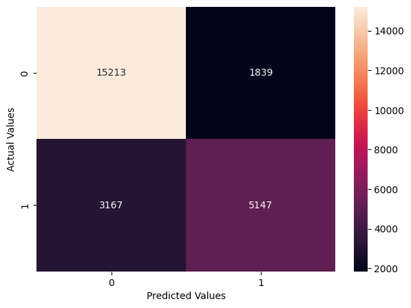

```python
cm = confusion_matrix(y_train, pred_train)
plt.figure(figsize=(7, 5))
sns.heatmap(cm, annot=True, fmt="g")
plt.xlabel("Predicted Values")
plt.ylabel("Actual Values")
plt.show()
```

The confusion matrix

- True Positives (TP): A person has cancelled booking and the model predicted customer has cancelld.
- True Negatives (TN): A person doesn't cance booking and the model predicted as not cancelled.
- False Positives (FP): The model predicted customer has cancelled but the person didn't.
- False Negatives (FN): The model predicted person doesn't cancelled booking but the person actually cancelled.

```python
print("Accuracy on training set : ", accuracy_score(y_train, pred_train))
```

```
Accuracy on training set :  0.8026492154852953
```

## Checking for Multicollinearity

```python
# let's check the VIF of the predictors
# Use X_train_numeric which is already processed to be fully numeric and has problematic columns handled
vif_series = pd.Series(
    [variance_inflation_factor(X_train_numeric.values, i) for i in range(X_train_numeric.shape[1])],
    index=X_train_numeric.columns,
    dtype=float,
)
print("VIF values: \n\n{}\n".format(vif_series))
```

```
VIF values:

const                                  88.58774
no_of_adults                            1.33319
no_of_children                          1.92952
no_of_weekend_nights                    1.05897
no_of_week_nights                       1.09381
required_car_parking_space              1.03436
lead_time                               1.21899
repeated_guest                          1.74723
no_of_previous_cancellations            1.36975
no_of_previous_bookings_not_canceled    1.63998
avg_price_per_room                      1.79137
no_of_special_requests                  1.22139
type_of_meal_plan_Meal Plan 2           1.19467
type_of_meal_plan_Meal Plan 3           1.01558
type_of_meal_plan_Not Selected          1.24390
room_type_reserved_Room_Type 2          1.08915
room_type_reserved_Room_Type 3          1.00097
room_type_reserved_Room_Type 4          1.36528
room_type_reserved_Room_Type 5          1.02390
room_type_reserved_Room_Type 6          1.91929
room_type_reserved_Room_Type 7          1.09004
market_segment_type_Corporate           5.26035
market_segment_type_Offline            18.79470
market_segment_type_Online             21.22195
dtype: float64
```

## if VIF>5 but its not of concerned as the variable with high VIF is categorical so now we will drop variables with hight p-value as they are insignificant for the model description.

Removing insignificant variables (p-value > 0.05 )

```python
# summary of initial logistic regression model
print(lg.summary())
```

```
                           Logit Regression Results
==============================================================================
Dep. Variable:         booking_status   No. Observations:                25366
Model:                          Logit   Df Residuals:                    25342
Method:                           MLE   Df Model:                           23
Date:                Sat, 16 May 2026   Pseudo R-squ.:                  0.3238
Time:                        08:31:22   Log-Likelihood:                -10851.
converged:                       True   LL-Null:                       -16046.
Covariance Type:            nonrobust   LLR p-value:                     0.000
========================================================================================================
                                           coef    std err          z      P>|z|      [0.025      0.975]
--------------------------------------------------------------------------------------------------------
const                                   -3.3020      0.230    -14.327      0.000      -3.754      -2.850
no_of_adults                             0.0220      0.037      0.589      0.556      -0.051       0.095
no_of_children                           0.1684      0.057      2.951      0.003       0.057       0.280
no_of_weekend_nights                     0.1520      0.020      7.675      0.000       0.113       0.191
no_of_week_nights                        0.0452      0.012      3.674      0.000       0.021       0.069
required_car_parking_space              -1.5948      0.136    -11.711      0.000      -1.862      -1.328
lead_time                                0.0158      0.000     62.462      0.000       0.015       0.016
repeated_guest                          -2.2210      0.587     -3.781      0.000      -3.372      -1.070
no_of_previous_cancellations             0.2493      0.091      2.734      0.006       0.071       0.428
no_of_previous_bookings_not_canceled    -0.1750      0.166     -1.054      0.292      -0.500       0.150
avg_price_per_room                       0.0190      0.001     27.312      0.000       0.018       0.020
no_of_special_requests                  -1.4916      0.030    -49.908      0.000      -1.550      -1.433
type_of_meal_plan_Meal Plan 2            0.0502      0.063      0.793      0.428      -0.074       0.174
type_of_meal_plan_Meal Plan 3            3.1820      3.102      1.026      0.305      -2.899       9.263
type_of_meal_plan_Not Selected           0.3012      0.052      5.757      0.000       0.199       0.404
room_type_reserved_Room_Type 2          -0.3031      0.129     -2.352      0.019      -0.556      -0.051
room_type_reserved_Room_Type 3           0.7195      1.511      0.476      0.634      -2.242       3.681
room_type_reserved_Room_Type 4          -0.1969      0.053     -3.721      0.000      -0.301      -0.093
room_type_reserved_Room_Type 5          -0.8156      0.215     -3.786      0.000      -1.238      -0.393
room_type_reserved_Room_Type 6          -1.0602      0.148     -7.175      0.000      -1.350      -0.771
room_type_reserved_Room_Type 7          -1.5014      0.327     -4.595      0.000      -2.142      -0.861
market_segment_type_Corporate           -0.6777      0.240     -2.825      0.005      -1.148      -0.207
market_segment_type_Offline             -1.5774      0.227     -6.959      0.000      -2.022      -1.133
market_segment_type_Online               0.2075      0.224      0.927      0.354      -0.231       0.646
========================================================================================================
```

```python
X_train1 = X_train.drop("type_of_meal_plan_Meal Plan 2", axis=1)
```

```python
# Based on the previous finding, X_train_numeric was correctly preprocessed.
# We will use that as the base for X_train1.
X_train1 = X_train_numeric.drop("type_of_meal_plan_Meal Plan 2", axis=1)

# fitting the model on training set with increased maxiter and suppressed disp
logit1 = sm.Logit(y_train, X_train1)
lg1 = logit1.fit(maxiter=1000, disp=False)

# Predicting on the training set
pred_train1 = (lg1.predict(X_train1) > 0.5).astype(int)


print("Accuracy on training set : ", accuracy_score(y_train, pred_train1))
```

```
Accuracy on training set :  0.8032799810770322
```

- There is no significant change in the model performance as compared to initial model.

```python
# checking summary of the model
print(lg1.summary())
```

```
                           Logit Regression Results
==============================================================================
Dep. Variable:         booking_status   No. Observations:                25366
Model:                          Logit   Df Residuals:                    25343
Method:                           MLE   Df Model:                           22
Date:                Sat, 16 May 2026   Pseudo R-squ.:                  0.3238
Time:                        08:31:23   Log-Likelihood:                -10851.
converged:                       True   LL-Null:                       -16046.
Covariance Type:            nonrobust   LLR p-value:                     0.000
========================================================================================================
                                           coef    std err          z      P>|z|      [0.025      0.975]
--------------------------------------------------------------------------------------------------------
const                                   -3.3093      0.230    -14.364      0.000      -3.761      -2.858
no_of_adults                             0.0228      0.037      0.612      0.541      -0.050       0.096
no_of_children                           0.1678      0.057      2.942      0.003       0.056       0.280
no_of_weekend_nights                     0.1522      0.020      7.685      0.000       0.113       0.191
no_of_week_nights                        0.0447      0.012      3.639      0.000       0.021       0.069
required_car_parking_space              -1.5961      0.136    -11.721      0.000      -1.863      -1.329
lead_time                                0.0158      0.000     62.825      0.000       0.015       0.016
repeated_guest                          -2.2197      0.587     -3.779      0.000      -3.371      -1.069
no_of_previous_cancellations             0.2488      0.091      2.727      0.006       0.070       0.428
no_of_previous_bookings_not_canceled    -0.1746      0.166     -1.052      0.293      -0.500       0.151
avg_price_per_room                       0.0191      0.001     28.076      0.000       0.018       0.020
no_of_special_requests                  -1.4910      0.030    -49.922      0.000      -1.550      -1.432
type_of_meal_plan_Meal Plan 3            3.1806      3.134      1.015      0.310      -2.962       9.323
type_of_meal_plan_Not Selected           0.2998      0.052      5.733      0.000       0.197       0.402
room_type_reserved_Room_Type 2          -0.3036      0.129     -2.355      0.019      -0.556      -0.051
room_type_reserved_Room_Type 3           0.7178      1.512      0.475      0.635      -2.245       3.681
room_type_reserved_Room_Type 4          -0.2007      0.053     -3.809      0.000      -0.304      -0.097
room_type_reserved_Room_Type 5          -0.8222      0.215     -3.820      0.000      -1.244      -0.400
room_type_reserved_Room_Type 6          -1.0678      0.147     -7.240      0.000      -1.357      -0.779
room_type_reserved_Room_Type 7          -1.5163      0.326     -4.646      0.000      -2.156      -0.877
market_segment_type_Corporate           -0.6816      0.240     -2.840      0.005      -1.152      -0.211
market_segment_type_Offline             -1.5713      0.227     -6.934      0.000      -2.015      -1.127
market_segment_type_Online               0.2029      0.224      0.906      0.365      -0.236       0.642
========================================================================================================
```

```python
X_train2 = X_train1.drop("market_segment_type_Online", axis=1)
```

```python
# fitting the model on training set
logit2 = sm.Logit(y_train, X_train2.astype(float))
lg2 = logit2.fit()

pred_train2 = lg2.predict(X_train2)
pred_train2 = np.round(pred_train2)

print("Accuracy on training set : ", accuracy_score(y_train, pred_train2))
```

```
Optimization terminated successfully.
         Current function value: 0.427798
         Iterations 11
Accuracy on training set :  0.8038319009698021
```

- There is no significant change in the model performance as compared to initial model.

```python
## checking summary of the model
print(lg2.summary())
```

```
                           Logit Regression Results
==============================================================================
Dep. Variable:         booking_status   No. Observations:                25366
Model:                          Logit   Df Residuals:                    25344
Method:                           MLE   Df Model:                           21
Date:                Sat, 16 May 2026   Pseudo R-squ.:                  0.3237
Time:                        08:31:23   Log-Likelihood:                -10852.
converged:                       True   LL-Null:                       -16046.
Covariance Type:            nonrobust   LLR p-value:                     0.000
========================================================================================================
                                           coef    std err          z      P>|z|      [0.025      0.975]
--------------------------------------------------------------------------------------------------------
const                                   -3.1238      0.103    -30.225      0.000      -3.326      -2.921
no_of_adults                             0.0268      0.037      0.725      0.468      -0.046       0.099
no_of_children                           0.1684      0.057      2.952      0.003       0.057       0.280
no_of_weekend_nights                     0.1521      0.020      7.681      0.000       0.113       0.191
no_of_week_nights                        0.0445      0.012      3.622      0.000       0.020       0.069
required_car_parking_space              -1.5972      0.136    -11.729      0.000      -1.864      -1.330
lead_time                                0.0158      0.000     63.013      0.000       0.015       0.016
repeated_guest                          -2.2402      0.587     -3.818      0.000      -3.390      -1.090
no_of_previous_cancellations             0.2509      0.091      2.749      0.006       0.072       0.430
no_of_previous_bookings_not_canceled    -0.1746      0.166     -1.049      0.294      -0.501       0.151
avg_price_per_room                       0.0192      0.001     28.336      0.000       0.018       0.021
no_of_special_requests                  -1.4902      0.030    -49.918      0.000      -1.549      -1.432
type_of_meal_plan_Meal Plan 3            3.0852      3.011      1.025      0.305      -2.816       8.986
type_of_meal_plan_Not Selected           0.3028      0.052      5.802      0.000       0.201       0.405
room_type_reserved_Room_Type 2          -0.3009      0.129     -2.335      0.020      -0.554      -0.048
room_type_reserved_Room_Type 3           0.6803      1.490      0.457      0.648      -2.240       3.600
room_type_reserved_Room_Type 4          -0.2042      0.053     -3.886      0.000      -0.307      -0.101
room_type_reserved_Room_Type 5          -0.8242      0.215     -3.831      0.000      -1.246      -0.403
room_type_reserved_Room_Type 6          -1.0717      0.147     -7.271      0.000      -1.361      -0.783
room_type_reserved_Room_Type 7          -1.5247      0.326     -4.674      0.000      -2.164      -0.885
market_segment_type_Corporate           -0.8777      0.103     -8.540      0.000      -1.079      -0.676
market_segment_type_Offline             -1.7715      0.050    -35.512      0.000      -1.869      -1.674
========================================================================================================
```

Dropping room_type_reserved_Room_Type 3 with highest p-value

```python
X_train3 = X_train2.drop("room_type_reserved_Room_Type 3", axis=1)
```

```python
# fitting the model on training set
logit3 = sm.Logit(y_train, X_train3.astype(float))
lg3 = logit3.fit()

pred_train3 = lg3.predict(X_train3)
pred_train3 = np.round(pred_train3)

print("Accuracy on training set : ", accuracy_score(y_train, pred_train3))
```

```
Optimization terminated successfully.
         Current function value: 0.427802
         Iterations 11
Accuracy on training set :  0.8038319009698021
```

There is no significant change in the model performance as compared to initial model.

```python
print(lg3.summary())
```

```
                           Logit Regression Results
==============================================================================
Dep. Variable:         booking_status   No. Observations:                25366
Model:                          Logit   Df Residuals:                    25345
Method:                           MLE   Df Model:                           20
Date:                Sat, 16 May 2026   Pseudo R-squ.:                  0.3237
Time:                        08:31:24   Log-Likelihood:                -10852.
converged:                       True   LL-Null:                       -16046.
Covariance Type:            nonrobust   LLR p-value:                     0.000
========================================================================================================
                                           coef    std err          z      P>|z|      [0.025      0.975]
--------------------------------------------------------------------------------------------------------
const                                   -3.1230      0.103    -30.222      0.000      -3.326      -2.920
no_of_adults                             0.0268      0.037      0.724      0.469      -0.046       0.099
no_of_children                           0.1684      0.057      2.952      0.003       0.057       0.280
no_of_weekend_nights                     0.1521      0.020      7.681      0.000       0.113       0.191
no_of_week_nights                        0.0445      0.012      3.618      0.000       0.020       0.069
required_car_parking_space              -1.5972      0.136    -11.729      0.000      -1.864      -1.330
lead_time                                0.0158      0.000     63.013      0.000       0.015       0.016
repeated_guest                          -2.2404      0.587     -3.818      0.000      -3.390      -1.090
no_of_previous_cancellations             0.2509      0.091      2.749      0.006       0.072       0.430
no_of_previous_bookings_not_canceled    -0.1746      0.166     -1.049      0.294      -0.501       0.151
avg_price_per_room                       0.0192      0.001     28.332      0.000       0.018       0.021
no_of_special_requests                  -1.4902      0.030    -49.922      0.000      -1.549      -1.432
type_of_meal_plan_Meal Plan 3            3.0850      3.010      1.025      0.305      -2.814       8.984
type_of_meal_plan_Not Selected           0.3027      0.052      5.800      0.000       0.200       0.405
room_type_reserved_Room_Type 2          -0.3011      0.129     -2.337      0.019      -0.554      -0.049
room_type_reserved_Room_Type 4          -0.2042      0.053     -3.886      0.000      -0.307      -0.101
room_type_reserved_Room_Type 5          -0.8242      0.215     -3.830      0.000      -1.246      -0.402
room_type_reserved_Room_Type 6          -1.0715      0.147     -7.269      0.000      -1.360      -0.783
room_type_reserved_Room_Type 7          -1.5244      0.326     -4.673      0.000      -2.164      -0.885
market_segment_type_Corporate           -0.8780      0.103     -8.543      0.000      -1.079      -0.677
market_segment_type_Offline             -1.7717      0.050    -35.517      0.000      -1.869      -1.674
========================================================================================================
```

Dropping no_of_adults with highest p-value

```python
X_train4 = X_train3.drop("no_of_adults", axis=1)
```

```python
# fitting the model on training set
logit4 = sm.Logit(y_train, X_train4.astype(float))
lg4 = logit4.fit()

pred_train4 = lg4.predict(X_train4)
pred_train4 = np.round(pred_train4)

print("Accuracy on training set : ", accuracy_score(y_train, pred_train4))
```

```
Optimization terminated successfully.
         Current function value: 0.427813
         Iterations 11
Accuracy on training set :  0.80347709532445
```

- There is no significant change in the model performance as compared to initial model.

```python
print(lg4.summary())
```

```
                           Logit Regression Results
==============================================================================
Dep. Variable:         booking_status   No. Observations:                25366
Model:                          Logit   Df Residuals:                    25346
Method:                           MLE   Df Model:                           19
Date:                Sat, 16 May 2026   Pseudo R-squ.:                  0.3237
Time:                        08:31:24   Log-Likelihood:                -10852.
converged:                       True   LL-Null:                       -16046.
Covariance Type:            nonrobust   LLR p-value:                     0.000
========================================================================================================
                                           coef    std err          z      P>|z|      [0.025      0.975]
--------------------------------------------------------------------------------------------------------
const                                   -3.0852      0.089    -34.636      0.000      -3.260      -2.911
no_of_children                           0.1640      0.057      2.888      0.004       0.053       0.275
no_of_weekend_nights                     0.1529      0.020      7.730      0.000       0.114       0.192
no_of_week_nights                        0.0445      0.012      3.622      0.000       0.020       0.069
required_car_parking_space              -1.5950      0.136    -11.718      0.000      -1.862      -1.328
lead_time                                0.0158      0.000     63.433      0.000       0.015       0.016
repeated_guest                          -2.2453      0.588     -3.822      0.000      -3.397      -1.094
no_of_previous_cancellations             0.2516      0.091      2.758      0.006       0.073       0.430
no_of_previous_bookings_not_canceled    -0.1750      0.167     -1.049      0.294      -0.502       0.152
avg_price_per_room                       0.0193      0.001     28.774      0.000       0.018       0.021
no_of_special_requests                  -1.4881      0.030    -50.113      0.000      -1.546      -1.430
type_of_meal_plan_Meal Plan 3            3.0863      3.009      1.026      0.305      -2.812       8.984
type_of_meal_plan_Not Selected           0.3052      0.052      5.862      0.000       0.203       0.407
room_type_reserved_Room_Type 2          -0.3048      0.129     -2.366      0.018      -0.557      -0.052
room_type_reserved_Room_Type 4          -0.1958      0.051     -3.823      0.000      -0.296      -0.095
room_type_reserved_Room_Type 5          -0.8235      0.215     -3.824      0.000      -1.246      -0.401
room_type_reserved_Room_Type 6          -1.0660      0.147     -7.238      0.000      -1.355      -0.777
room_type_reserved_Room_Type 7          -1.5113      0.326     -4.640      0.000      -2.150      -0.873
market_segment_type_Corporate           -0.8897      0.102     -8.765      0.000      -1.089      -0.691
market_segment_type_Offline             -1.7737      0.050    -35.602      0.000      -1.871      -1.676
========================================================================================================
```

```python
X_train5 = X_train4.drop("type_of_meal_plan_Meal Plan 3", axis=1)
```

```python
# fitting the model on training set
logit5 = sm.Logit(y_train, X_train5.astype(float))
lg5 = logit5.fit()

pred_train5 = lg5.predict(X_train5)
pred_train5 = np.round(pred_train5)

print("Accuracy on training set : ", accuracy_score(y_train, pred_train5))
```

```
Optimization terminated successfully.
         Current function value: 0.427842
         Iterations 11
Accuracy on training set :  0.8034376724749664
```

There is no significant change in the model performance as compared to initial model

```python
print(lg5.summary())
```

```
                           Logit Regression Results
==============================================================================
Dep. Variable:         booking_status   No. Observations:                25366
Model:                          Logit   Df Residuals:                    25347
Method:                           MLE   Df Model:                           18
Date:                Sat, 16 May 2026   Pseudo R-squ.:                  0.3237
Time:                        08:31:24   Log-Likelihood:                -10853.
converged:                       True   LL-Null:                       -16046.
Covariance Type:            nonrobust   LLR p-value:                     0.000
========================================================================================================
                                           coef    std err          z      P>|z|      [0.025      0.975]
--------------------------------------------------------------------------------------------------------
const                                   -3.0867      0.089    -34.646      0.000      -3.261      -2.912
no_of_children                           0.1636      0.057      2.881      0.004       0.052       0.275
no_of_weekend_nights                     0.1528      0.020      7.726      0.000       0.114       0.192
no_of_week_nights                        0.0445      0.012      3.621      0.000       0.020       0.069
required_car_parking_space              -1.5952      0.136    -11.720      0.000      -1.862      -1.328
lead_time                                0.0158      0.000     63.429      0.000       0.015       0.016
repeated_guest                          -2.2443      0.587     -3.820      0.000      -3.396      -1.093
no_of_previous_cancellations             0.2515      0.091      2.757      0.006       0.073       0.430
no_of_previous_bookings_not_canceled    -0.1749      0.167     -1.049      0.294      -0.502       0.152
avg_price_per_room                       0.0193      0.001     28.798      0.000       0.018       0.021
no_of_special_requests                  -1.4882      0.030    -50.114      0.000      -1.546      -1.430
type_of_meal_plan_Not Selected           0.3053      0.052      5.862      0.000       0.203       0.407
room_type_reserved_Room_Type 2          -0.3043      0.129     -2.362      0.018      -0.557      -0.052
room_type_reserved_Room_Type 4          -0.1963      0.051     -3.833      0.000      -0.297      -0.096
room_type_reserved_Room_Type 5          -0.8243      0.215     -3.827      0.000      -1.246      -0.402
room_type_reserved_Room_Type 6          -1.0670      0.147     -7.244      0.000      -1.356      -0.778
room_type_reserved_Room_Type 7          -1.5075      0.326     -4.624      0.000      -2.146      -0.869
market_segment_type_Corporate           -0.8898      0.102     -8.765      0.000      -1.089      -0.691
market_segment_type_Offline             -1.7729      0.050    -35.593      0.000      -1.871      -1.675
========================================================================================================
```

Dropping no_of_previous_bookings_not_canceled with highest p-value

```python
X_train6 = X_train5.drop('no_of_previous_bookings_not_canceled', axis =1 )
```

```python
# fitting the model on training set
logit6 = sm.Logit(y_train, X_train6.astype(float))
lg6 = logit6.fit()

pred_train6 = lg6.predict(X_train6)
pred_train6 = np.round(pred_train6)

print("Accuracy on training set : ", accuracy_score(y_train, pred_train6))
```

```
Optimization terminated successfully.
         Current function value: 0.427887
         Iterations 9
Accuracy on training set :  0.8033588267759993
```

```python
print(lg6.summary())
```

```
                           Logit Regression Results
==============================================================================
Dep. Variable:         booking_status   No. Observations:                25366
Model:                          Logit   Df Residuals:                    25348
Method:                           MLE   Df Model:                           17
Date:                Sat, 16 May 2026   Pseudo R-squ.:                  0.3236
Time:                        08:31:25   Log-Likelihood:                -10854.
converged:                       True   LL-Null:                       -16046.
Covariance Type:            nonrobust   LLR p-value:                     0.000
==================================================================================================
                                     coef    std err          z      P>|z|      [0.025      0.975]
--------------------------------------------------------------------------------------------------
const                             -3.0875      0.089    -34.650      0.000      -3.262      -2.913
no_of_children                     0.1636      0.057      2.881      0.004       0.052       0.275
no_of_weekend_nights               0.1528      0.020      7.727      0.000       0.114       0.192
no_of_week_nights                  0.0445      0.012      3.620      0.000       0.020       0.069
required_car_parking_space        -1.5947      0.136    -11.715      0.000      -1.861      -1.328
lead_time                          0.0158      0.000     63.446      0.000       0.015       0.016
repeated_guest                    -2.6230      0.531     -4.943      0.000      -3.663      -1.583
no_of_previous_cancellations       0.2108      0.082      2.567      0.010       0.050       0.372
avg_price_per_room                 0.0193      0.001     28.804      0.000       0.018       0.021
no_of_special_requests            -1.4886      0.030    -50.127      0.000      -1.547      -1.430
type_of_meal_plan_Not Selected     0.3053      0.052      5.864      0.000       0.203       0.407
room_type_reserved_Room_Type 2    -0.3044      0.129     -2.363      0.018      -0.557      -0.052
room_type_reserved_Room_Type 4    -0.1965      0.051     -3.837      0.000      -0.297      -0.096
room_type_reserved_Room_Type 5    -0.8244      0.215     -3.829      0.000      -1.246      -0.402
room_type_reserved_Room_Type 6    -1.0673      0.147     -7.245      0.000      -1.356      -0.779
room_type_reserved_Room_Type 7    -1.5081      0.326     -4.626      0.000      -2.147      -0.869
market_segment_type_Corporate     -0.8942      0.102     -8.803      0.000      -1.093      -0.695
market_segment_type_Offline       -1.7726      0.050    -35.589      0.000      -1.870      -1.675
==================================================================================================
```

```python
# fitting the model on training set
logit6 = sm.Logit(y_train, X_train6.astype(float))
lg6 = logit6.fit()

pred_train6 = lg6.predict(X_train6)
pred_train6 = np.round(pred_train6)

print("Accuracy on training set : ", accuracy_score(y_train, pred_train6))
```

```
Optimization terminated successfully.
         Current function value: 0.427887
         Iterations 9
Accuracy on training set :  0.8033588267759993
```

- Now all the columns left are significant predictors, let's check the model performance and make interpretations.